# Text Analysis: Jane Austen and Louisa May Alcott novels

###### Author: Frank Liang

```python
#Import python libraries needed for the assignment
import glob, math, nltk
import pandas as pd
import matplotlib.pyplot as plt
nltk.download('stopwords')
```

```
True
```

```python
# Below contains basic text processing functions
def preprocess(s, lowercase=True, strip_punctuation=True):
    """
    Input:
        string s
        boolean lowercase
        boolean strip_punctuation
    Return:
        list of strings after preprocessing
    """
    punctuation = '.,?<>:;"\'!%[]_`*-'
    if isinstance(s, str):
        s = tokenize(s)
    if lowercase:
        s = [t.lower() for t in s]
    if strip_punctuation:
        s = [t.strip(punctuation) for t in s]
    s = [t for t in s if t !='']

    return s

def tokenize(text):
    return text.split()

def token_frequency(text, relative=False):
    """
    Input:
        text - list of strings
    Return:
        freqs - a dictionary contains the token_frequency
    """
    freqs = {}
    for token in text:
        if token in freqs:
            freqs[token] += 1
        else:
            freqs[token] = 1
    if relative:
        total = len(text)
        for token in freqs:
            freqs[token] = freqs[token]/total
    return freqs

def document_frequency(tfs_list):
    """
    Input:
        tfs_list - a list of token frequencies
    Return:
        df - a dictionary contains the document frequency
    """
    df = {}
    for tf in tfs_list:
        for token in tf:
            if token in df:
                df[token] += 1
            else:
                df[token] = 1
    return df

def cartesian_distance(v1, v2):
    """
    Input:
        v1, v2 - two dictionaries with feature & frequency pairs
    Return:
        cartesian_distance between v1 and v2
    """
    dist = 0
    for feature in set(list(v1.keys())+list(v2.keys())):
        if feature in v1 and feature in v2:
            dist += (v1[feature]-v2[feature])**2
        elif feature in v1 and feature not in v2:
            dist += (v1[feature]-0)**2
        else:
            dist += (v2[feature]-0)**2
    return dist**0.5

def token_group_frequency(tf, featureset_list):
    """
    Input:
        tf - a dictionary of token frequency
        featureset_list - a list of list of features as a group
    Return:
        vec - a list contains the token group frequency
    """
    vec = []

    for featureset in featureset_list:
        f = 0
        for feature in featureset:
            if feature in tf:
                f += tf[feature]
        vec.append(f)
    return vec

def chunk_corpus(text, chunksize):
    """
    Input:
        text - list of strings
        chunksize - int
    Return:
        chunks - a list of strings where each string is a chunk of chunksize
    """
    chunks = []
    for start in range(0, len(text)-chunksize+1, chunksize):
        chunk = text[start:start+chunksize]
        chunks.append(chunk)
    return chunks
```

### First we get the word chunks of 5000

```python
#Chunk the novels into 5000 word chunks, left over at the end will be ignored
chunksize = 5000

corpus = [] # corpus list contains the novel chunks of size 5000
labels = [] # label list for each chunk
file_path = '/Users/liangningyue/Documents/SP22Course/IPH432/austen_alcott/*.txt'
file_paths = glob.glob(file_path) # get all the file paths for the novels
for fp in file_paths:
    text = preprocess(open(fp, 'r').read()) #preprocess the text
    chunks = chunk_corpus(text, 5000) # chunk the text into chunks of size 5000
    corpus.extend(chunks)
    label_root = fp.split('/')[-1][:-4]
    for i, c in enumerate(chunks):
        label = '{}_{:04d}'.format(label_root, i) # format the label of the chunk as author_title_chunk number
        labels.append(label)
print(len(corpus)) # we get 239 chunks in total
```

```
239
```

### Then, we choose three ways to turn the chunks into vectors based on different feature sets:

```python
# feature set 1: stopwords form nltk.corpus
from nltk.corpus import stopwords
stop_word_features = stopwords.words('english')

# get the vector dictionary for each chunk based on the stop word feature set
vector_dicts_1 = []
for c in corpus:
    tf = token_frequency(c)
    v = {k:tf[k] for k in tf if k in stop_word_features}
    vector_dicts_1.append(v)
```

```python
# get the stop word vectors for each chunk from the vector dictionary
from sklearn.feature_extraction import DictVectorizer
vectorizer1 = DictVectorizer(sparse=False)
stop_word_vectors = vectorizer1.fit_transform(vector_dicts_1)
stop_word_features = vectorizer1.feature_names_
```

```python
# feature set 2: group significant meaning carrying words(top 100 tfidf words) in each novel as a feature,
# and add to the feature set

file_path = '/Users/liangningyue/Documents/SP22Course/IPH432/austen_alcott/*.txt'
novel_token_freqs = []
file_paths = glob.glob(file_path)
for fp in file_paths:
    tokens = preprocess(open(fp, 'r').read())
    novel_token_freqs.append(token_frequency(tokens, relative=True)) #Get the token frequency of novels

df = document_frequency(novel_token_freqs) #Get the document frequency
corpus_tfidf_features = []

# calculate the tfidf scores in each novel
for novel in novel_token_freqs:
    tfidf = {}
    for token in novel:
        token_tfidf = novel[token] * math.log((len(file_paths)/df[token]))
        tfidf[token] = token_tfidf
    # sorted the tfidf scores to get the top 100 tfidf words
    tfidf_sorted = sorted(tfidf.items(), key = lambda x: x[1], reverse=True)[:100]
    # eliminate words with a document frequency <= 2
    tfidf_subset = [w for w,tfidf in tfidf_sorted if df[w]>2]
    # add to the feature set as a feature
    corpus_tfidf_features.append(tfidf_subset)

# get the vector for each chunk based on the top tfidf word group feature set
corpus_tfidf_vectors = []
for c in corpus:
    tf = token_frequency(c)
    tf_group = token_group_frequency(tf, corpus_tfidf_features)
    corpus_tfidf_vectors.append(tf_group)
```

```python
# Method 3: topic modeling
from sklearn.decomposition import LatentDirichletAllocation
from sklearn.feature_extraction import DictVectorizer

no_topics = 10 #choose the number of topics as 10
file_path = '/Users/liangningyue/Documents/SP22Course/IPH432/austen_alcott/*.txt'
file_paths = glob.glob(file_path)
stop_words = stopwords.words('english')
# get vectors based on token frequency
vectors = []
for c in corpus:
    #remove stop words influence in topic modeling
    c = [w for w in c if df[w] != len(file_paths)]
    tf = token_frequency(c, relative = True)
    vectors.append(tf)

vectorizer = DictVectorizer(sparse=False)
vectors = vectorizer.fit_transform(vectors)
features = vectorizer.feature_names_
# apply topic modeling
lda = LatentDirichletAllocation(n_components=no_topics, max_iter=5, random_state = 1).fit(vectors)
topic_model_vectors = lda.transform(vectors)
```

```python
# dataframe for further investigating the topic model through chunk-topic distributions & topic-word distribution
topic_names = [f'Topic {k}' for k in range (10)]
topic_word_distributions = pd.DataFrame(lda.components_, columns = features, index = topic_names)
chunk_topic_distributions = pd.DataFrame(topic_model_vectors, columns = topic_names)
```

### Run K-Means clustering on the chunks with N=2 and Visualize the clusters using PCA

```python
from sklearn.cluster import KMeans
n_clusters=2 # classfied into two clusters
from sklearn.decomposition import PCA
```

#### Method 1: K-Means clustering on the chunks with N=2 based on the stopword feature set

```python
kmeans_model1 = KMeans(n_clusters=n_clusters, random_state=0)
stop_word_kmeans = kmeans_model1.fit(stop_word_vectors)
#Cluster 0: austen novels; Cluster 1: alcott novels. Wrong classifications may exist
for nc in range(n_clusters):
    print("\nCluster {}:".format(nc))
    cluster_labels = [l for i, l in enumerate(labels) if stop_word_kmeans.labels_[i]==nc]
    print(', '.join(cluster_labels))
```

```
Cluster 0:
austen_sense_and_sensibility_0000, austen_sense_and_sensibility_0001, austen_sense_and_sensibility_0002, austen_sense_and_sensibility_0003, austen_sense_and_sensibility_0004, austen_sense_and_sensibility_0005, austen_sense_and_sensibility_0006, austen_sense_and_sensibility_0007, austen_sense_and_sen…

Cluster 1:
alcott_little_men_0000, alcott_little_men_0001, alcott_little_men_0002, alcott_little_men_0003, alcott_little_men_0004, alcott_little_men_0005, alcott_little_men_0006, alcott_little_men_0007, alcott_little_men_0008, alcott_little_men_0009, alcott_little_men_0010, alcott_little_men_0011, alcott_littl…
```

```python
# calculate the classification accuracy rate by author
austen_correct1 = [i for i, l in enumerate(stop_word_kmeans.labels_) if l==0 and labels[i].split('_')[0] == 'austen']
alcott_correct1 = [i for i, l in enumerate(stop_word_kmeans.labels_) if l==1 and labels[i].split('_')[0] == 'alcott']
accuracy_rate1 = (len(austen_correct1)+len(alcott_correct1))/(len(stop_word_kmeans.labels_))*100
print("The accuracy rate of chunks classified by author: {0:.2f} %".format(accuracy_rate1))
```

```
The accuracy rate of chunks classified by author: 100.00 %
```

```python
# Adjust the kmeans labels for visualize the clusters using PCA as follow:
adjusted_stopword_labels = []
for i, l in enumerate(stop_word_kmeans.labels_):
    if l==0 and labels[i].split('_')[0] == 'austen': # 0: correctly clustered Austen texts;
        adjusted_stopword_labels.append(0)
    elif l==1 and labels[i].split('_')[0] == 'alcott': # 1: correctly clustered Alcott texts;
        adjusted_stopword_labels.append(1)
    elif l==1 and labels[i].split('_')[0] == 'austen': # 2: incorrectly clustered Austen texts;
        adjusted_stopword_labels.append(2)
    else:                                             # 3: incorrectly clustered Alcott texts;
        adjusted_stopword_labels.append(3)
```

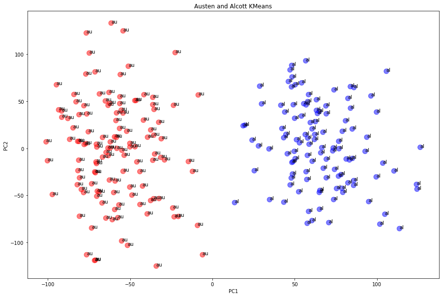

```python
#Visualize the clusters using PCA and with correctly clustered Austen texts as red;
# correctly clustered Alcott texts as blue; incorrectly clustered Austen texts as orange;
# incorrectly clustered Alcott texts as purple.
pca1 = PCA(n_components=2)
transformed = pca1.fit_transform(stop_word_vectors)
x = transformed[:,0]
y = transformed[:,1]

col_dict = {0:'red', 1:'blue', 2:'orange', 3:'purple'}
cols = [col_dict[l] for l in adjusted_stopword_labels]

plt.figure(figsize=(15,10))
plt.scatter(x,y, c=cols, s=100, alpha=.5)
for i, l in enumerate(labels):
    plt.text(x[i],y[i], '{}'.format(labels[i][:2]))
plt.xlabel('PC1')
plt.ylabel('PC2')
plt.title('Austen and Alcott KMeans')
plt.show()
```

#### Method 2: K-Means clustering on the chunks with N=2 based on the top tfidf group feature set

```python
kmeans_model2 = KMeans(n_clusters=n_clusters, random_state=0)
corpus_tfidf_kmeans = kmeans_model2.fit(corpus_tfidf_vectors)
#Cluster 0: alcott novels; Cluster 1: austen novels. Wrong classifications may exist
for nc in range(n_clusters):
    print("\nCluster {}:".format(nc))
    cluster_labels = [l for i, l in enumerate(labels) if corpus_tfidf_kmeans.labels_[i]==nc]
    print(', '.join(cluster_labels))
```

```
Cluster 0:
alcott_little_men_0000, alcott_little_men_0001, alcott_little_men_0002, alcott_little_men_0003, alcott_little_men_0004, alcott_little_men_0005, alcott_little_men_0006, alcott_little_men_0007, alcott_little_men_0008, alcott_little_men_0009, alcott_little_men_0010, alcott_little_men_0011, alcott_littl…

Cluster 1:
austen_sense_and_sensibility_0000, austen_sense_and_sensibility_0001, austen_sense_and_sensibility_0002, austen_sense_and_sensibility_0003, austen_sense_and_sensibility_0004, austen_sense_and_sensibility_0005, austen_sense_and_sensibility_0006, austen_sense_and_sensibility_0007, austen_sense_and_sen…
```

```python
# calculate the classification accuracy rate by author
austen_correct2 = [i for i, l in enumerate(corpus_tfidf_kmeans.labels_) if l==1 and labels[i].split('_')[0] == 'austen']
alcott_correct2 = [i for i, l in enumerate(corpus_tfidf_kmeans.labels_) if l==0 and labels[i].split('_')[0] == 'alcott']
accuracy_rate2 = (len(austen_correct2)+len(alcott_correct2))/(len(corpus_tfidf_kmeans.labels_))*100
#get the wrong classified label index for further investigate
austen_incorrect_tfidf = [i for i, l in enumerate(corpus_tfidf_kmeans.labels_) if l==0 and labels[i].split('_')[0] == 'austen']
alcott_incorrect_tfidf = [i for i, l in enumerate(corpus_tfidf_kmeans.labels_) if l==1 and labels[i].split('_')[0] == 'alcott']
print("The accuracy rate of chunks classified by author: {0:.2f} %".format(accuracy_rate2))
```

```
The accuracy rate of chunks classified by author: 98.33 %
```

```python
# Adjust the kmeans labels for visualize the clusters using PCA as follow:
adjusted_tfidf_labels = []
for i, l in enumerate(corpus_tfidf_kmeans.labels_):
    if l==1 and labels[i].split('_')[0] == 'austen': # 0: correctly clustered Austen texts;
        adjusted_tfidf_labels.append(0)
    elif l==0 and labels[i].split('_')[0] == 'alcott': # 1: correctly clustered Alcott texts;
        adjusted_tfidf_labels.append(1)
    elif l==0 and labels[i].split('_')[0] == 'austen': # 2: incorrectly clustered Austen texts;
        adjusted_tfidf_labels.append(2)
    else:  # 3: incorrectly clustered Alcott texts;
        adjusted_tfidf_labels.append(3)
```

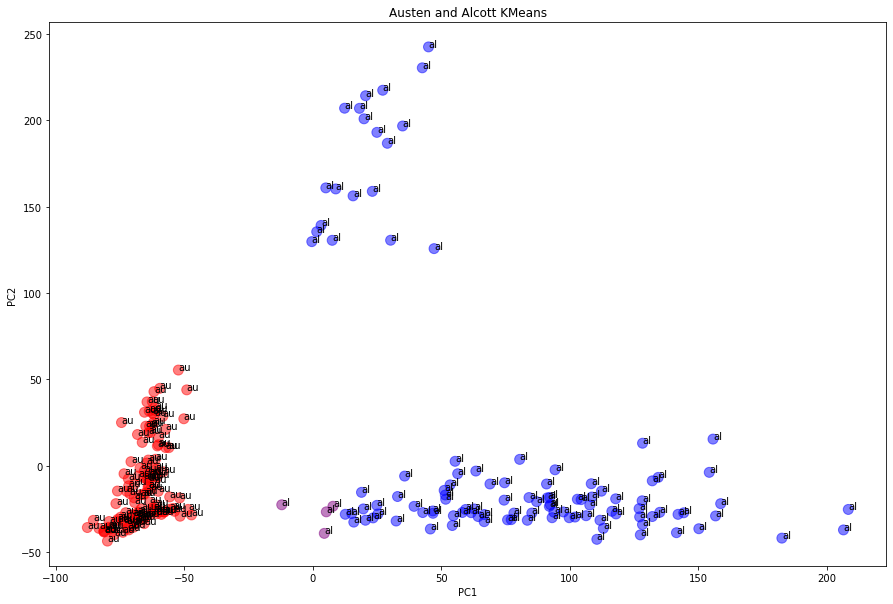

```python
#Visualize the clusters using PCA and with correctly clustered Austen texts as red;
# correctly clustered Alcott texts as blue; incorrectly clustered Austen texts as orange;
# incorrectly clustered Alcott texts as purple.
pca2 = PCA(n_components=2)
transformed = pca2.fit_transform(corpus_tfidf_vectors)
x = transformed[:,0]
y = transformed[:,1]

col_dict = {0:'red', 1:'blue', 2:'orange', 3:'purple'}
cols = [col_dict[l] for l in adjusted_tfidf_labels]

plt.figure(figsize=(15,10))
plt.scatter(x,y, c=cols, s=100, alpha=.5)
for i, l in enumerate(labels):
    plt.text(x[i],y[i], '{}'.format(labels[i][:2]))
plt.xlabel('PC1')
plt.ylabel('PC2')
plt.title('Austen and Alcott KMeans')
plt.show()
```

#### Method 3: K-Means clustering on the chunks with N=2 based on topic modeling vectors

```python
kmeans_model3 = KMeans(n_clusters=n_clusters, random_state=0)
topic_model_kmeans = kmeans_model3.fit(topic_model_vectors)
#Cluster 0: alcott novels; Cluster 1: austen novels. Wrong classifications may exist
for nc in range(n_clusters):
    print("\nCluster {}:".format(nc))
    cluster_labels = [l for i, l in enumerate(labels) if topic_model_kmeans.labels_[i]==nc]
    print(', '.join(cluster_labels))
```

```
Cluster 0:
alcott_little_men_0000, alcott_little_men_0001, alcott_little_men_0002, alcott_little_men_0003, alcott_little_men_0004, alcott_little_men_0005, alcott_little_men_0006, alcott_little_men_0007, alcott_little_men_0008, alcott_little_men_0009, alcott_little_men_0010, alcott_little_men_0011, alcott_littl…

Cluster 1:
austen_sense_and_sensibility_0000, austen_sense_and_sensibility_0001, austen_sense_and_sensibility_0002, austen_sense_and_sensibility_0003, austen_sense_and_sensibility_0004, austen_sense_and_sensibility_0005, austen_sense_and_sensibility_0006, austen_sense_and_sensibility_0007, austen_sense_and_sen…
```

```python
# calculate the classification accuracy rate by author
austen_correct3 = [i for i, l in enumerate(topic_model_kmeans.labels_) if l==1 and labels[i].split('_')[0] == 'austen']
alcott_correct3 = [i for i, l in enumerate(topic_model_kmeans.labels_) if l==0 and labels[i].split('_')[0] == 'alcott']
accuracy_rate3 = (len(austen_correct3)+len(alcott_correct3))/(len(topic_model_kmeans.labels_))*100
#get the wrong classified label index for further investigate
austen_incorrect_topic = [i for i, l in enumerate(topic_model_kmeans.labels_) if l==0 and labels[i].split('_')[0] == 'austen']
alcott_incorrect_topic = [i for i, l in enumerate(topic_model_kmeans.labels_) if l==1 and labels[i].split('_')[0] == 'alcott']
print("The accuracy rate of chunks classified by author: {0:.2f} %".format(accuracy_rate3))
```

```
The accuracy rate of chunks classified by author: 92.05 %
```

```python
# Adjust the kmeans labels for visualize the clusters using PCA as follow:
adjusted_topic_labels = []
for i, l in enumerate(topic_model_kmeans.labels_):
    if l==1 and labels[i].split('_')[0] == 'austen': # 0: correctly clustered Austen texts;
        adjusted_topic_labels.append(0)
    elif l==0 and labels[i].split('_')[0] == 'alcott':  #1: correctly clustered Alcott texts;
        adjusted_topic_labels.append(1)
    elif l==0 and labels[i].split('_')[0] == 'austen': # 2: incorrectly clustered Austen texts;
        adjusted_topic_labels.append(2)
    else: #3: incorrectly clustered Alcott texts;
        adjusted_topic_labels.append(3)
```

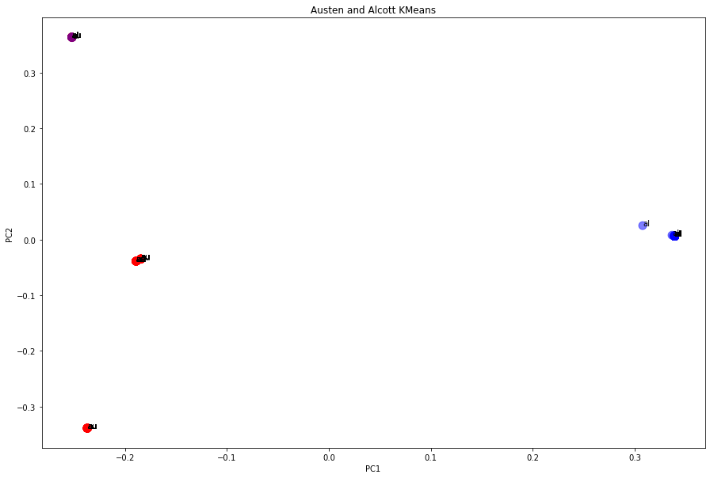

```python
#Visualize the clusters using PCA and with correctly clustered Austen texts as red;
# correctly clustered Alcott texts as blue; incorrectly clustered Austen texts as orange;
# incorrectly clustered Alcott texts as purple.
pca3 = PCA(n_components=2)
transformed = pca3.fit_transform(topic_model_vectors)
x = transformed[:,0]
y = transformed[:,1]

# set labels
col_dict = {0:'red', 1:'blue', 2:'orange', 3:'purple'}
cols = [col_dict[l] for l in adjusted_topic_labels]

plt.figure(figsize=(15,10))
plt.scatter(x,y, c=cols, s=100, alpha=.5)
for i, l in enumerate(labels):
    plt.text(x[i],y[i], '{}'.format(labels[i][:2]))
plt.xlabel('PC1')
plt.ylabel('PC2')
plt.title('Austen and Alcott KMeans')
plt.show()
```

### Further analysis of the results with the essay

#### Stop word feature set analysis:

```python
# number of chunks of Alcott novels
print(len(alcott_correct1))
# number of chunks of Austen novels
print(len(austen_correct1))
```

```
113
126
```

```python
# calculate the top 10 most commonly used stop words by Austen in all novels
stop_word_austen = {}
# calculate the top 10 most commonly used stop words by Alcott in all novels
stop_word_alcott = {}
for i, dic in enumerate(vector_dicts_1):
    if labels[i].split('_')[0] == 'austen':
        for word in dic:
            if word in stop_word_austen: # compute frequency relatively
                stop_word_austen[word] += (int) (dic[word]*len(alcott_correct1)/len(austen_correct1))
            else:
                stop_word_austen[word] = (int) (dic[word]*len(alcott_correct1)/len(austen_correct1))
    else:
        for word in dic:
            if word in stop_word_alcott:
                stop_word_alcott[word] += dic[word]
            else:
                stop_word_alcott[word] = dic[word]
```

```python
#the top 10 most commonly used stop words by Austen in all novels
stop_word_austen_sorted =sorted(stop_word_austen.items(), key = lambda x: x[1], reverse=True)[:10]
stop_word_austen_sorted
```

```
[('the', 20188),
 ('to', 18867),
 ('and', 17117),
 ('of', 16409),
 ('a', 10263),
 ('her', 9920),
 ('was', 8736),
 ('i', 8649),
 ('in', 8492),
 ('she', 7791)]
```

```python
# the top 10 most commonly used stop words by Alcott in all novels
stop_word_alcott_sorted =sorted(stop_word_alcott.items(), key = lambda x: x[1], reverse=True)[:10]
stop_word_alcott_sorted
```

```
[('and', 24181),
 ('the', 23034),
 ('to', 15300),
 ('a', 13695),
 ('of', 10559),
 ('i', 9788),
 ('her', 9245),
 ('it', 7673),
 ('in', 7489),
 ('she', 6970)]
```

#### Top tf-idf word feature set analysis:

```python
# each feature mainly contains novel characters' names, nouns, and some adjectives
print(file_paths[4])
print(corpus_tfidf_features[4])
```

```
/Users/liangningyue/Documents/SP22Course/IPH432/austen_alcott/austen_emma.txt
['emma', 'bates', 'martin', 'campbell', 'smith', 'attachment', 'jane', 'chuse', 'abbey', 'maple', "body's", 'robert', 'connexion', 'situation', 'weymouth', 'frank', 'pianoforte', "jane's", 'circumstance', 'ireland', 'london', 'extraordinary', 'intimacy', 'henry', 'patty', 'shew', 'completely', 'favo…
```

```python
# Compute Austen's and Alcott's most common meaning carrying words
meaning_carrying_austen = {}
meaning_carrying_alcott = {}

feature_author = []
for i, feature in enumerate(corpus_tfidf_features):
    if (file_paths[i].split('/')[-1][:-4].split('_')[0]) == 'austen':
        feature_author.append('austen')
        for word in feature:
            if word in meaning_carrying_austen:
                meaning_carrying_austen[word] += 1
            else:
                meaning_carrying_austen[word] = 1
    else:
        feature_author.append('alcott')
        for word in feature:
            if word in meaning_carrying_alcott:
                meaning_carrying_alcott[word] += 1
            else:
                meaning_carrying_alcott[word] = 1
```

```python
#the most commonly used meaning carrying words by Austen in all novels
meaning_carrying_austen_sorted =sorted(meaning_carrying_austen.items(), key = lambda x: x[1], reverse=True)[:10]
print(meaning_carrying_austen_sorted)
```

```
[('attachment', 5), ('situation', 3), ('favour', 3), ('london', 3), ('smith', 3), ('circumstance', 3), ('connexion', 3), ('fanny', 2), ('behaviour', 2), ('robert', 2)]
```

```python
# the most commonly used meaning carrying words by Alcott in all novels
meaning_carrying_alcott_sorted =sorted(meaning_carrying_alcott.items(), key = lambda x: x[1], reverse=True)[:10]
print(meaning_carrying_alcott_sorted)
```

```
[('big', 5), ("won't", 5), ("didn't", 4), ("i'm", 4), ("it's", 4), ("isn't", 4), ("i'll", 4), ('em', 4), ("wouldn't", 4), ('fun', 4)]
```

```python
# misclassified cases:
print(austen_incorrect_tfidf)
print(alcott_incorrect_tfidf)
```

```
[]
[75, 181, 184, 192]
```

```python
print(corpus_tfidf_vectors[181])

print(feature_author)
print(corpus_tfidf_features[0])
print(labels[181])
print(sorted(token_frequency(corpus[181]).items(), key = lambda x: x[1], reverse=True)[:50])
```

```
[15, 25, 30, 2, 1, 1, 18, 51, 30, 3]
['austen', 'alcott', 'alcott', 'austen', 'austen', 'austen', 'alcott', 'alcott', 'alcott', 'austen']
['edward', 'lucy', 'margaret', 'fanny', 'colonel', 'behaviour', 'robert', 'attachment', 'charlotte', 'cottage', 'situation', 'connection', "john's", 'engagement', 'favour', 'expectation', 'exceedingly', 'mama', 'particulars', 'favourite', 'london', 'aye', 'smith', 'censure', 'disposition', 'estate',…
alcott_work_0002
[('the', 225), ('and', 220), ('her', 154), ('a', 129), ('to', 126), ('of', 103), ('she', 99), ('in', 74), ('with', 73), ('for', 67), ('was', 63), ('as', 60), ('it', 52), ('that', 51), ('christie', 41), ('had', 35), ('but', 35), ('i', 35), ('you', 28), ('when', 26), ('on', 26), ('his', 26), ('if', 23…
```

#### Topic model feature set analysis:

```python
#get an overview of chunk distribution on each topic
chunk_topic_distributions
```

|  | Topic 0 | Topic 1 | Topic 2 | Topic 3 | Topic 4 | Topic 5 | Topic 6 | Topic 7 | Topic 8 | Topic 9 |
| --- | --- | --- | --- | --- | --- | --- | --- | --- | --- | --- |
| 0 | 0.050042 | 0.050040 | 0.050067 | 0.050043 | 0.050010 | 0.549760 | 0.050010 | 0.050010 | 0.050010 | 0.050010 |
| 1 | 0.050026 | 0.050019 | 0.050019 | 0.050017 | 0.050009 | 0.549872 | 0.050009 | 0.050009 | 0.050009 | 0.050009 |
| 2 | 0.050021 | 0.050016 | 0.050022 | 0.050030 | 0.050010 | 0.549861 | 0.050010 | 0.050010 | 0.050010 | 0.050010 |
| 3 | 0.050023 | 0.050017 | 0.050018 | 0.050025 | 0.050009 | 0.549875 | 0.050009 | 0.050009 | 0.050009 | 0.050009 |
| 4 | 0.050027 | 0.050018 | 0.050020 | 0.050023 | 0.050008 | 0.549871 | 0.050008 | 0.050008 | 0.050008 | 0.050008 |
| ... | ... | ... | ... | ... | ... | ... | ... | ... | ... | ... |
| 234 | 0.549566 | 0.050016 | 0.050125 | 0.050014 | 0.050009 | 0.050234 | 0.050009 | 0.050009 | 0.050009 | 0.050009 |
| 235 | 0.549882 | 0.050019 | 0.050027 | 0.050014 | 0.050009 | 0.050016 | 0.050009 | 0.050009 | 0.050009 | 0.050009 |
| 236 | 0.549875 | 0.050017 | 0.050036 | 0.050014 | 0.050008 | 0.050016 | 0.050008 | 0.050008 | 0.050008 | 0.050008 |
| 237 | 0.549874 | 0.050021 | 0.050028 | 0.050015 | 0.050009 | 0.050017 | 0.050009 | 0.050009 | 0.050009 | 0.050009 |
| 238 | 0.549781 | 0.050017 | 0.050118 | 0.050014 | 0.050009 | 0.050024 | 0.050009 | 0.050009 | 0.050009 | 0.050009 |

239 rows × 10 columns

#### Based on the chunk_topic_distributions, we get the topic with most distribution for each novel

Topic 0 : austen_persuasion; austen_pride_and_prejudice; Topic 5 : austen_sense_and_sensibility; Topic 3 : austen_emma; Topic 1 : austen_mansfield_park;

Topic 2 : alcott_little_women; alcott_work, alcott_eight_cousins; Topic 5 : alcott_an_old-fashioned_girl;

```python
#misclassified cases
print(alcott_incorrect_topic)
```

```
[159, 160, 161, 162, 163, 165, 166, 167, 168, 169, 170, 171, 172, 173, 174, 175, 176, 177, 178]
```

```python
for i in alcott_incorrect_topic:
    print(labels[i])
```

```
alcott_an_old-fashioned_girl_0000
alcott_an_old-fashioned_girl_0001
alcott_an_old-fashioned_girl_0002
alcott_an_old-fashioned_girl_0003
alcott_an_old-fashioned_girl_0004
alcott_an_old-fashioned_girl_0006
alcott_an_old-fashioned_girl_0007
alcott_an_old-fashioned_girl_0008
alcott_an_old-fashioned_girl_0009
alcott_an_old-fashioned_girl_0010
alcott_an_old-fashioned_girl_0011
alcott_an_old-fashioned_girl_0012
alcott_an_old-fashioned_girl_0013
alcott_an_old-fashioned_girl_0014
alcott_an_old-fashioned_girl_0015
alcott_an_old-fashioned_girl_0016
alcott_an_old-fashioned_girl_0017
alcott_an_old-fashioned_girl_0018
alcott_an_old-fashioned_girl_0019
```

The misclassified cases are all chunks from the same novel "alcott_an_old-fashioned_girl" which is mainly related to topic 5. The austen_sense_and_sensibility is also corresponding to this same topic, which causes the wrong classification

```python
# topics distributed most with austen novels
print(topic_word_distributions.loc['Topic 0'].sort_values(ascending=False).head(18))
print()
print(topic_word_distributions.loc['Topic 3'].sort_values(ascending=False).head(18))
print()
print(topic_word_distributions.loc['Topic 1'].sort_values(ascending=False).head(18))
print()
print(topic_word_distributions.loc['Topic 5'].sort_values(ascending=False).head(18))
```

```
elizabeth    0.832241
anne         0.632740
captain      0.470528
darcy        0.470356
“i           0.422177
elliot       0.408349
bennet       0.403501
jane         0.380909
bingley      0.357833
wentworth    0.329949
charles      0.298879
mary         0.287505
wickham      0.265564
collins      0.261555
letter       0.256268
anything     0.245737
musgrove     0.240965
lydia        0.229798
Name: Topic 0, dtype: float64

emma         1.036922
weston       0.585976
harriet      0.585758
knightley    0.522714
elton        0.500590
jane         0.437497
woodhouse    0.424533
fairfax      0.349725
frank        0.338435
churchill    0.335346
hartfield    0.292004
highbury     0.256675
bates        0.254535
letter       0.231570
randalls     0.208795
harriet's    0.207878
emma's       0.197767
martin       0.186439
Name: Topic 3, dtype: float64

```

[output cut: 24 more lines]

```
marianne      0.684486
s             0.530527
fanny         0.472369
dashwood      0.371062
jennings      0.352304
fan           0.342356
edward        0.340263
ll            0.336730
m             0.325783
maud          0.324479
willoughby    0.315971
lucy          0.294595
colonel       0.290005
can't         0.250810
Name: Topic 5, dtype: float64
```

```python
# topics distributed most with alcott novels
print(topic_word_distributions.loc['Topic 2'].sort_values(ascending=False).head(30))
print()
print(topic_word_distributions.loc['Topic 5'].sort_values(ascending=False).head(30))
print()
```

```
jo          1.643155
christie    0.991970
i'm         0.875713
meg         0.745323
laurie      0.711826
amy         0.688076
it's        0.650278
i'll        0.644188
beth        0.521567
bhaer       0.500637
won't       0.491789
dan         0.478466
can't       0.465100
demi        0.428441
didn't      0.426036
david       0.417813
march       0.407069
nat         0.399864
i've        0.394238
i'd         0.338150
daisy       0.323107
nan         0.320860
that's      0.320426
big         0.305752
anything    0.304031
tommy       0.298062
wouldn't    0.292983
isn't       0.291220
teddy       0.281244
alec        0.266929
Name: Topic 2, dtype: float64

polly         1.331970
elinor        0.860472
tom           0.725359
n't           0.697348
marianne      0.684486
s             0.530527
fanny         0.472369
dashwood      0.371062
```

[output cut: 8 more lines]

```
colonel       0.290005
can't         0.250810
d             0.245038
won't         0.239682
anything      0.237800
brandon       0.230750
shaw          0.230632
polly's       0.227984
ferrars       0.220190
ve            0.218808
middleton     0.211172
letter        0.206847
barton        0.201439
trix          0.192765
Name: Topic 5, dtype: float64
```